# Practice notebook for univariate analysis using NHANES data

This notebook will give you the opportunity to perform some univariate analyses on your own using the NHANES. These analyses are similar to what was done in the week 2 NHANES case study notebook.

You can enter your code into the cells that say "enter your code here", and you can type responses to the questions into the cells that say "Type Markdown and Latex".

Note that most of the code that you will need to write below is very similar to code that appears in the case study notebook. You will need to edit code from that notebook in small ways to adapt it to the prompts below.

To get started, we will use the same module imports and read the data in the same way as we did in the case study:

```python
%matplotlib inline
import matplotlib.pyplot as plt
import seaborn as sns
import pandas as pd
import statsmodels.api as sm
import numpy as np

da = pd.read_csv("nhanes_2015_2016.csv")
```

## Question 1

Relabel the marital status variable DMDMARTL to have brief but informative character labels. Then construct a frequency table of these values for all people, then for women only, and for men only. Then construct these three frequency tables using only people whose age is between 30 and 40.

```python
da["DMDMARTLx"] = da.DMDMARTL.replace({1 : "Married", 2 : "Widowed", 3 : "Divorced", 4 : "Separated",
                                       5 : "Never Married", 6 : "Living with partner", 77 : "Refused",
                                      99 : "Don't Know"}).dropna()

dafreqall = da.DMDMARTLx.value_counts()
print("frequency of marital status for all:")
print(dafreqall)
print(dafreqall / dafreqall.sum())

dawomen = da[da.RIAGENDR == 2] # Women are 2
dafreqwomen = dawomen.DMDMARTLx.value_counts()
print("")
print("frequency of marital status for women:")
print(dafreqwomen)
print(dafreqwomen / dafreqwomen.sum())

damen = da[da.RIAGENDR == 1] # Men are 1
dafreqmen = damen.DMDMARTLx.value_counts()
print("")
print("frequency of marital status for men:")
print(dafreqmen)
print(dafreqmen / dafreqmen.sum())

da30_40 = da[(da.RIDAGEYR >= 30) & (da.RIDAGEYR <= 40)]
dafreqall30_40 = da30_40.DMDMARTLx.value_counts()
print("frequency of marital status for all aged 30-40:")
print(dafreqall30_40)
print(dafreqall30_40 / dafreqall30_40.sum())

dawomen30_40 = dawomen[(dawomen.RIDAGEYR >= 30) & (dawomen.RIDAGEYR <= 40)]
dafreqwomen30_40 = dawomen30_40.DMDMARTLx.value_counts()
print("")
print("frequency of marital status for women aged 30-40:")
print(dafreqwomen30_40)
print(dafreqwomen30_40 / dafreqwomen30_40.sum())

damen30_40 = damen[(damen.RIDAGEYR >= 30) & (damen.RIDAGEYR <= 40)]
dafreqmen30_40 = damen30_40.DMDMARTLx.value_counts()
print("")
print("frequency of marital status for men aged 30-40:")
print(dafreqmen30_40)
print(dafreqmen30_40 / dafreqmen30_40.sum())
```

```
frequency of marital status for all:
Married                2780
Never Married          1004
Divorced                579
Living with partner     527
Widowed                 396
Separated               186
Refused                   2
Name: DMDMARTLx, dtype: int64
Married                0.507855
Never Married          0.183412
Divorced               0.105773
Living with partner    0.096273
Widowed                0.072342
Separated              0.033979
Refused                0.000365
Name: DMDMARTLx, dtype: float64

frequency of marital status for women:
Married                1303
Never Married           520
Divorced                350
Widowed                 296
Living with partner     262
Separated               118
Refused                   1
Name: DMDMARTLx, dtype: int64
Married                0.457193
Never Married          0.182456
Divorced               0.122807
Widowed                0.103860
Living with partner    0.091930
Separated              0.041404
Refused                0.000351
Name: DMDMARTLx, dtype: float64

frequency of marital status for men:
Married                1477
Never Married           484
Living with partner     265
```

[output cut: 49 more lines]

```
Never Married          101
Living with partner     78
Divorced                24
Separated               12
Widowed                  3
Refused                  1
Name: DMDMARTLx, dtype: int64
Married                0.556680
Never Married          0.204453
Living with partner    0.157895
Divorced               0.048583
Separated              0.024291
Widowed                0.006073
Refused                0.002024
Name: DMDMARTLx, dtype: float64
```

**Q1a.** Briefly comment on some of the differences that you observe between the distribution of marital status between women and men, for people of all ages.

Men are married more than women, and it appears it may be because they re-marry at a higher rate after being divorced or widowed.

**Q1b.** Briefly comment on the differences that you observe between the distribution of marital status states for women between the overall population, and for women between the ages of 30 and 40.

Women aged 30-40 are less likely to be divorced and far less likely to be widowed. Women do get married for the first time after age 40, but it is not likely.

**Q1c.** Repeat part b for the men.

Men aged 30-40 have rarely had their marriages ended, but they are much more likely to be unmarried and living together than that.

## Question 2

Restricting to the female population, stratify the subjects into age bands no wider than ten years, and construct the distribution of marital status within each age band. Within each age band, present the distribution in terms of proportions that must sum to 1.

```python
import pandas as pd

da = pd.read_csv("nhanes_2015_2016.csv")

da["DMDMARTLx"] = da.DMDMARTL.replace({1 : "Married", 2 : "Widowed",
                                       3 : "Divorced", 4 : "Separated",
                                       5 : "Never Married",
                                       6 : "Living with partner",
                                       77 : "Refused",
                                       99 : "Don't Know"}).dropna()
da["RIAGENDRx"] = da.RIAGENDR.replace({1 : "Male", 2 : "Female"})

da = da[da.RIAGENDRx == "Female"]
da = da[da.DMDMARTLx != "Don't Know"]

da["agegrp"] = pd.cut(da.RIDAGEYR, list(range(10, 81, 10)))
da = da.groupby("agegrp")["DMDMARTLx"]
da = da.value_counts()
da = da.unstack()
da = da.apply(lambda x: x/x.sum(), axis=1)
da = da.fillna(0)
print(da)
```

```
DMDMARTLx  Divorced  Living with partner   Married  Never Married   Refused  \
agegrp
(10, 20]   0.000000             0.205128  0.025641       0.769231  0.000000
(20, 30]   0.021401             0.206226  0.305447       0.445525  0.000000
(30, 40]   0.090717             0.120253  0.544304       0.204641  0.000000
(40, 50]   0.137450             0.073705  0.573705       0.125498  0.000000
(50, 60]   0.176596             0.068085  0.546809       0.089362  0.002128
(60, 70]   0.192744             0.043084  0.480726       0.086168  0.000000
(70, 80]   0.143902             0.007317  0.317073       0.051220  0.000000

DMDMARTLx  Separated   Widowed
agegrp
(10, 20]    0.000000  0.000000
(20, 30]    0.021401  0.000000
(30, 40]    0.035865  0.004219
(40, 50]    0.065737  0.023904
(50, 60]    0.057447  0.059574
(60, 70]    0.049887  0.147392
(70, 80]    0.019512  0.460976
```

**Q2a.** Comment on the trends that you see in this series of marginal distributions.

Never married drops considerably for each age range except 60-69, so women in their 60's tend to not get married at all. For women in their 70's the drop in "Never Married" probably means that unmarried women are dying younger.

**Q2b.** Repeat the construction for males.

```python
import pandas as pd

da = pd.read_csv("nhanes_2015_2016.csv")

da["DMDMARTLx"] = da.DMDMARTL.replace({1 : "Married", 2 : "Widowed",
                                       3 : "Divorced", 4 : "Separated",
                                       5 : "Never Married",
                                       6 : "Living with partner",
                                       77 : "Refused",
                                       99 : "Don't Know"}).dropna()
da["RIAGENDRx"] = da.RIAGENDR.replace({1 : "Male", 2 : "Female"})

da = da[da.RIAGENDRx == "Male"]
da = da[da.DMDMARTLx != "Don't Know"]

da["agegrp"] = pd.cut(da.RIDAGEYR, list(range(10, 81, 10)))
da = da.groupby("agegrp")["DMDMARTLx"]
da = da.value_counts()
da = da.unstack()
da = da.apply(lambda x: x/x.sum(), axis=1)
da = da.fillna(0)
print(da)
```

```
DMDMARTLx  Divorced  Living with partner   Married  Never Married   Refused  \
agegrp
(10, 20]   0.000000             0.075000  0.025000       0.900000  0.000000
(20, 30]   0.004630             0.212963  0.238426       0.523148  0.000000
(30, 40]   0.052402             0.157205  0.563319       0.194323  0.002183
(40, 50]   0.084788             0.082294  0.703242       0.097257  0.000000
(50, 60]   0.125551             0.074890  0.651982       0.103524  0.000000
(60, 70]   0.125858             0.050343  0.665904       0.086957  0.000000
(70, 80]   0.141791             0.022388  0.611940       0.022388  0.000000

DMDMARTLx  Separated   Widowed
agegrp
(10, 20]    0.000000  0.000000
(20, 30]    0.016204  0.004630
(30, 40]    0.026201  0.004367
(40, 50]    0.027431  0.004988
(50, 60]    0.022026  0.022026
(60, 70]    0.032037  0.038902
(70, 80]    0.034826  0.166667
```

**Q2c.** Comment on any notable differences that you see when comparing these results for females and for males.

Unmarried men seem to be dying even younger compared to married men than women do. By the time men are in the 70s, almost 98% of them have married at some time.

## Question 3

Construct a histogram of the distribution of heights using the BMXHT variable in the NHANES sample.

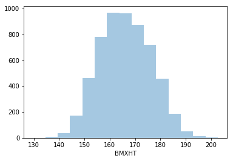

```python
import seaborn as sns
import pandas as pd

da = pd.read_csv("nhanes_2015_2016.csv")

sns.distplot(da.BMXHT.dropna(), kde=False, bins=15)
```

**Q3a.** Use the `bins` argument to [distplot](https://seaborn.pydata.org/generated/seaborn.distplot.html) to produce histograms with different numbers of bins. Assess whether the default value for this argument gives a meaningful result, and comment on what happens as the number of bins grows excessively large or excessively small.

Looking at the result for bins=100, there are too many peaks. At bins=5, wee see a clear maximum somewhere between 160 and 170. bins=10 doesn't clear anything up. bins=20 seems ideal because it shows a right-skew.

**Q3b.** Make separate histograms for the heights of women and men, then make a side-by-side boxplot showing the heights of women and men.

```
Histogram of heights for women
```

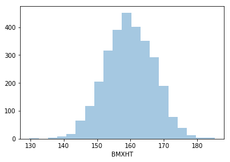

```
Histogram of heights for men
```

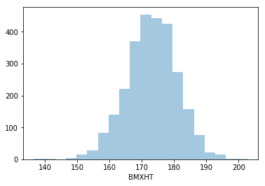

```
Boxplots for Men and Women
```

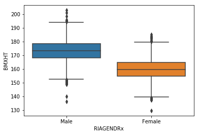

```python
import seaborn as sns
import pandas as pd
import matplotlib.pyplot as plt

da = pd.read_csv("nhanes_2015_2016.csv")

da["RIAGENDRx"] = da.RIAGENDR.replace({1 : "Male", 2 : "Female"})

daf = da[da.RIAGENDRx == "Female"]
dam = da[da.RIAGENDRx == "Male"]

print("Histogram of heights for women")
sns.distplot(daf.BMXHT.dropna(), kde=False, bins=20)
plt.show()

print("")
print("Histogram of heights for men")
sns.distplot(dam.BMXHT.dropna(), kde=False, bins=20)
plt.show()

print("")
print("Boxplots for Men and Women")
sns.boxplot(x="RIAGENDRx", y="BMXHT", data=da)
```

**Q3c.** Comment on what features, if any are not represented clearly in the boxplots, and what features, if any, are easier to see in the boxplots than in the histograms.

## Question 4

Make a boxplot showing the distribution of within-subject differences between the first and second systolic blood pressure measurents (BPXSY1 and BPXSY2).

```
count    5369.000000
mean       -0.674986
std         5.046465
min       -32.000000
25%        -4.000000
50%         0.000000
75%         2.000000
max        26.000000
Name: BPXSYdiff, dtype: float64

Boxplot for change in systolic blood pressure from second to first measurement
```

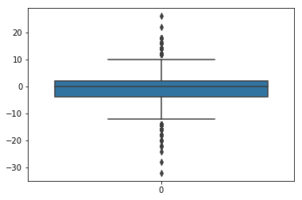

```python
import seaborn as sns
import pandas as pd

da = pd.read_csv("nhanes_2015_2016.csv")

da["BPXSYdiff"] = da.BPXSY2 - da.BPXSY1

da["BPXSYdiff"].dropna()

print(da.BPXSYdiff.describe())

print("")
print("Boxplot for change in systolic blood pressure from second to first"
      + " measurement")
sns.boxplot(data=da.BPXSYdiff)
```

**Q4a.** What proportion of the subjects have a lower SBP on the second reading compared to the first?

```python
import pandas as pd

da = pd.read_csv("nhanes_2015_2016.csv")

da["BPXSYdiff"] = da.BPXSY2 - da.BPXSY1
da["BPXSYdiff"].dropna()
dal = da[da.BPXSYdiff < 0]

prop_lower = dal.BPXSYdiff.count()/da.BPXSYdiff.count()
print("proportion of lower SBP on second reading is {}".format(prop_lower))
```

```
proportion of lower SBP on second reading is 0.45874464518532315
```

**Q4b.** Make side-by-side boxplots of the two systolic blood pressure variables.

```
Text(0,0.5,'Blood pressure in mm/Hg')
```

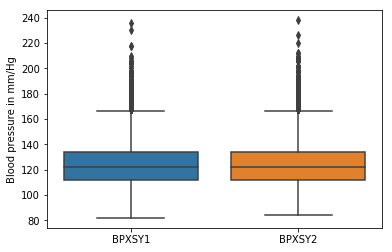

```python
import seaborn as sns
import pandas as pd

da = pd.read_csv("nhanes_2015_2016.csv")

dap = da.loc[:, ["BPXSY1", "BPXSY2"]]

sns.boxplot(data=dap).set_ylabel("Blood pressure in mm/Hg")
```

**Q4c.** Comment on the variation within either the first or second systolic blood pressure measurements, and the variation in the within-subject differences between the first and second systolic blood pressure measurements.

## Question 5

Construct a frequency table of household sizes for people within each educational attainment category (the relevant variable is DMDEDUC2). Convert the frequencies to proportions.

```python
import pandas as pd

da = pd.read_csv("nhanes_2015_2016.csv")

da["DMDEDUC2x"] = da.DMDEDUC2.replace({1 : "<9",
                                       2 : "9-11",
                                       3 : "HS/GED",
                                       4 : "Some College/AA",
                                       5 : "College",
                                       7 : "Refused",
                                       9: "Don't Know"}).dropna()
# da["RIAGENDRx"] = da.RIAGENDR.replace({1 : "Male", 2 : "Female"})

#da = da[da.RIAGENDRx == "Female"]
da = da[da.DMDEDUC2x != "Refused"]
da = da[da.DMDEDUC2x != "Don't Know"]

#da["agegrp"] = pd.cut(da.RIDAGEYR, list(range(10, 81, 10)))

da = da.groupby("DMDEDUC2x")["DMDHHSIZ"]
da = da.value_counts()
da = da.unstack()
da = da.apply(lambda x: x/x.sum(), axis=1)
da = da.fillna(0)
print(da)
```

```
DMDHHSIZ                1         2         3         4         5         6  \
DMDEDUC2x
9-11             0.116641  0.222395  0.163297  0.152411  0.146190  0.113530
<9               0.109924  0.224427  0.146565  0.132824  0.148092  0.108397
College          0.142753  0.347731  0.193997  0.165447  0.095168  0.029283
HS/GED           0.152614  0.270658  0.171164  0.161889  0.109612  0.065767
Some College/AA  0.151141  0.268970  0.193091  0.169031  0.122147  0.050586

DMDHHSIZ                7
DMDEDUC2x
9-11             0.085537
<9               0.129771
College          0.025622
HS/GED           0.068297
Some College/AA  0.045034
```

**Q5a.** Comment on any major differences among the distributions.

College graduates, in general, don't have large families.

**Q5b.** Restrict the sample to people between 30 and 40 years of age. Then calculate the median household size for women and men within each level of educational attainment.

```python
import pandas as pd

da = pd.read_csv("nhanes_2015_2016.csv")

edudict = {1 : "<9",
           2 : "9-11",
           3 : "HS/GED",
           4 : "Some College/AA",
           5 : "College",
           7 : "Refused",
           9: "Don't Know"}

sexdict = {1 : "men", 2 : "women"}

da = da[da.DMDEDUC2 != 7]
da = da[da.DMDEDUC2 != 9]
da = da[da.RIDAGEYR >= 30]
da = da[da.RIDAGEYR < 40]

for sex in range(1, 3):
    dasex = da[da['RIAGENDR']==sex]
    for edu in range(1, 6):
        dae = dasex[dasex["DMDEDUC2"]==edu]
        das = dae["DMDHHSIZ"].value_counts(sort=False)
        total = das.sum()
        med_loc_lower = (total / 2)
        if total % 2 == 0:
            med_loc_higher = med_loc_lower + 1
        else:
            med_loc_higher = med_loc_lower
        sum = 0
        for hhsize in range(1, 8):
            if hhsize in das:
                sum += das[hhsize]
            if sum >= med_loc_lower:
                if sum >= med_loc_higher:
                    median = float(hhsize)
                else:
                    median = hhsize+0.5
                break

        print("median household size for {} education level {} is {}"\
              .format(sexdict[sex], edudict[edu], median))
```

```
median household size for men education level <9 is 5.0
median household size for men education level 9-11 is 5.0
median household size for men education level HS/GED is 4.0
median household size for men education level Some College/AA is 4.0
median household size for men education level College is 3.0
median household size for women education level <9 is 5.0
median household size for women education level 9-11 is 5.0
median household size for women education level HS/GED is 5.0
median household size for women education level Some College/AA is 4.0
median household size for women education level College is 3.0
```

## Question 6

The participants can be clustered into "maked variance units" (MVU) based on every combination of the variables SDMVSTRA and SDMVPSU. Calculate the mean age (RIDAGEYR), height (BMXHT), and BMI (BMXBMI) for each gender (RIAGENDR), within each MVU, and report the ratio between the largest and smallest mean (e.g. for height) across the MVUs.

```python
import pandas as pd

da = pd.read_csv("nhanes_2015_2016.csv")

#for SDMVPSU in range(1, 3):
#    for SDMVSTRA in range(119, 134):
#        damvu = da[(da.SDMVPSU == SDMVPSU) & (da.SDMVSTRA == SDMVSTRA)]

sexdict = {1 : "men", 2 : "women"}
da["RIAGENDRx"] = da.RIAGENDR.replace(sexdict)

damvucl = da.groupby(['RIAGENDRx', 'SDMVPSU', 'SDMVSTRA']).mean()
damvucl = damvucl[['RIDAGEYR', 'BMXHT', 'BMXBMI']]
print(damvucl)

damvucl.reset_index(inplace=True)
damvuclmen = damvucl[damvucl['RIAGENDRx'] == "men"]
damvuclwomen = damvucl[damvucl['RIAGENDRx'] == "women"]

print("")
print("Ratios of largest to smallest means across MVUs:")
print("")
print("For men, age ratio is {}"\
      .format(damvuclmen['RIDAGEYR'].max()/damvuclmen['RIDAGEYR'].min()))
print("For men, height ratio is {}"\
      .format(damvuclmen['BMXHT'].max()/damvuclmen['BMXHT'].min()))
print("For men, BMI ratio is {}"\
      .format(damvuclmen['BMXBMI'].max()/damvuclmen['BMXBMI'].min()))
print("")
print("For women, age ratio is {}"\
      .format(damvuclwomen['RIDAGEYR'].max()/damvuclwomen['RIDAGEYR'].min()))
print("For women, height ratio is {}"\
      .format(damvuclwomen['BMXHT'].max()/damvuclwomen['BMXHT'].min()))
print("For women, BMI ratio is {}"\
      .format(damvuclwomen['BMXBMI'].max()/damvuclwomen['BMXBMI'].min()))
```

```
                             RIDAGEYR       BMXHT     BMXBMI
RIAGENDRx SDMVPSU SDMVSTRA
men       1       119       47.861111  172.741667  26.958333
                  120       43.130000  169.537755  30.939175
                  121       46.750000  172.177885  29.416505
                  122       44.653061  173.998969  28.528866
                  123       47.829787  174.315217  29.231522
                  124       50.750000  172.109009  28.614414
                  125       55.165289  173.631092  29.727731
                  126       48.416667  175.149398  29.033333
                  127       53.137931  171.545349  31.062353
                  128       53.673267  169.325000  31.749000
                  129       43.922222  171.094318  26.493182
                  130       50.516854  176.974157  30.337079
                  131       53.140187  175.610476  28.259615
```

[output cut: 57 more lines]

**Q6a.** Comment on the extent to which mean age, height, and BMI vary among the MVUs.

Age varies the most, followed by BMI. There is little variation in height.

**Q6b.** Calculate the inter-quartile range (IQR) for age, height, and BMI for each gender and each MVU. Report the ratio between the largest and smalles IQR across the MVUs.

```python
import pandas as pd

da = pd.read_csv("nhanes_2015_2016.csv")

#for SDMVPSU in range(1, 3):
#    for SDMVSTRA in range(119, 134):
#        damvu = da[(da.SDMVPSU == SDMVPSU) & (da.SDMVSTRA == SDMVSTRA)]

sexdict = {1 : "men", 2 : "women"}
da["RIAGENDRx"] = da.RIAGENDR.replace(sexdict)

damvuq1 = da.groupby(['RIAGENDRx', 'SDMVPSU', 'SDMVSTRA']).quantile(0.75)
damvuq1 = damvuq1[['RIDAGEYR', 'BMXHT', 'BMXBMI']]
print("")
print("First quartile:")
print("")
print(damvuq1)

damvuq3 = da.groupby(['RIAGENDRx', 'SDMVPSU', 'SDMVSTRA']).quantile(0.25)
damvuq3 = damvuq3[['RIDAGEYR', 'BMXHT', 'BMXBMI']]
print("")
print("Third quartile:")
print("")
print(damvuq3)

damvuiqrr = damvuq1 - damvuq3
print("")
print("IQR range:")
print("")
print(damvuiqrr)

damvuiqrr.reset_index(inplace=True)
dmen = damvuiqrr[damvuiqrr['RIAGENDRx'] == "men"]
dwomen = damvuiqrr[damvuiqrr['RIAGENDRx'] == "women"]

print("")
print("Ratios of largest to smallest IQR range across MVUs:")
print("")
print("For men, age range ratio is {}"\
      .format(dmen['RIDAGEYR'].max()/dmen['RIDAGEYR'].min()))
print("For men, height range ratio is {}"\
      .format(dmen['BMXHT'].max()/dmen['BMXHT'].min()))
print("For men, BMI range ratio is {}"\
      .format(dmen['BMXBMI'].max()/dmen['BMXBMI'].min()))
print("")
print("For women, age range ratio is {}"\
      .format(dwomen['RIDAGEYR'].max()/dwomen['RIDAGEYR'].min()))
print("For women, height range ratio is {}"\
      .format(dwomen['BMXHT'].max()/dwomen['BMXHT'].min()))
print("For women, BMI range ratio is {}"\
      .format(dwomen['BMXBMI'].max()/dwomen['BMXBMI'].min()))
```

```
First quartile:

0.75                        RIDAGEYR    BMXHT  BMXBMI
RIAGENDRx SDMVPSU SDMVSTRA
men       1       119          62.25  177.825  28.500
                  120          55.50  175.800  35.100
                  121          63.00  177.700  33.000
                  122          58.75  178.600  31.500
                  123          61.00  179.025  32.625
                  124          65.00  176.700  31.350
                  125          70.00  178.900  33.500
                  126          66.25  180.700  32.700
                  127          68.00  176.675  34.700
                  128          69.00  174.450  34.450
                  129          53.75  177.400  29.125
```

[output cut: 189 more lines]

**Q6c.** Comment on the extent to which the IQR for age, height, and BMI vary among the MVUs.

Men have higher variance among the MVUs than women, except for height they are the same